# Homework 1

Ella Marrero, David Morales, Brandon Powell, Joon Chae

2021-04-05

```r
library(lubridate)
```

## Simplify from Counts to presence

Create a dense dataframe of word presence – also going to be big. And a Y variable for use later.

```r
P = as.data.frame(as.matrix(spm>0))

stars = reviews$Score
```

Now we will build a function that will run each of our marginal regressions.

```r
margreg = function(p){
    fit = lm(stars~P[[p]])
    sf = summary(fit)
    return(sf$coef[2,4])
}
margreg(10) #the pval for the 10th word
```

```
## [1] 0.004430345
```

Coincidentally, word 10 looks pretty significant. What is it?

```r
words[10]
```

```
## [1] "addictive"
```

Okay, that explains that.

## Calculate Pvalues for every word

### Apply version

```r
pvals = sapply(1:length(words),margreg)
```

## Q1 Plot the p-values and comment on their distribution (2 sentence max).

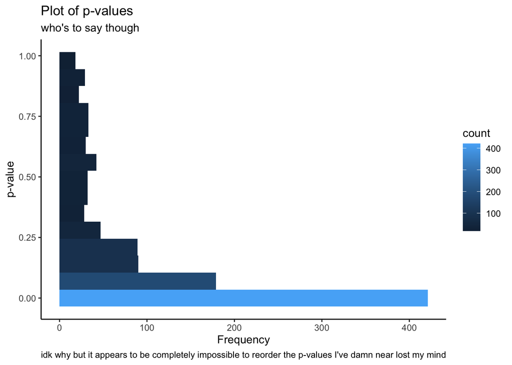

```r
ggplot()+
  geom_histogram(aes(pvals, fill = ..count..), binwidth = 0.07)+
  labs(title = 'Plot of p-values', subtitle = "who's to say though", x = 'p-value', y = 'Frequency', caption = "idk why but it appears to be completely impossible to reorder the p-values I've damn near lost my mind")+
  coord_flip()+
  theme_classic()
```

The distribution of p-values for these regressions is extremely right skewed with a very high concentration of small p-values; this suggests that an abundance of the words have a significant correlation to review rating.

## Q2 Let’s do standard statistical testing. How many tests are significant at the alpha level 0.05 and 0.01?

```r
alphas = c(0.05, 0.01)
for (alpha in alphas){
  print(paste("Tests significant at alpha =", alpha, ":" , length(pvals[pvals < alpha])))
}
```

```
## [1] "Tests significant at alpha = 0.05 : 461"
## [1] "Tests significant at alpha = 0.01 : 348"
```

## Q3 What is the p-value cutoff for 1% FDR? Plot the rejection region.

Benjamini & Hochberg: $\quad \alpha^{*}= \max\{p_{k}:p_{k}\leq q \frac{k}{K}\}$
$$q = 0.01 \quad K = 1125$$

$$\max \{p_{(k)} : \frac{1125 \times p_{(k)}}{k}\leq 0.01\}$$

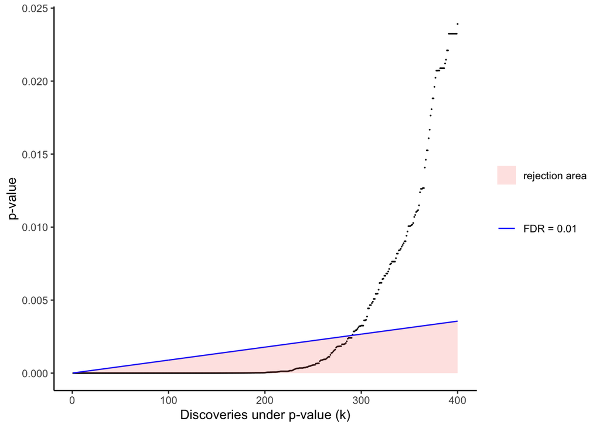

```r
K = 1125
q = 0.01
k = numeric(length(pvals))
pk = sort(pvals)
k = 1:length(pk)
plot_w = 1:400
ggplot() +
  theme_classic()+
  geom_point(aes(k[plot_w], pk[plot_w]), size = 0.01)+

  geom_line(aes(k[plot_w], ((q/K)*k)[plot_w], color = 'FDR = 0.01'))+
  geom_area(aes(k[plot_w], ((q/K)*k)[plot_w], fill = 'rejection area'), alpha = 0.2)+
  labs(x = 'Discoveries under p-value (k)', y = 'p-value')+
  theme(legend.title = element_blank()) +
  scale_color_manual(values = c('blue'), labels = c('FDR = 0.01'))
```

```r
p_cutoff = pk[length(pk[(1125 * pk)/k <= 0.01])]
print(paste('P-value cutoff for 1% FDR:', p_cutoff))
```

```
## [1] "P-value cutoff for 1% FDR: 0.00241324881985225"
```

## Q4 How many discoveries do you find at q=0.01 and how many do you expect to be false?

At q = 0.01, we find 289 discoveries and expect 2.7149049 to be false.

## Q5 What are the 10 most significant words? Was ‘addictive’ significant’? Do these results make sense to you? (2 sentence max)

```r
for (i in 1:10){
  rank = i
  print(paste(rank, words[pvals == pk[i]]))
}
```

```
## [1] "1 not"
## [1] "2 horrible"
## [1] "3 great"
## [1] "4 bad"
## [1] "5 nasty"
## [1] "6 disappointed"
## [1] "7 new"
## [1] "8 but"
## [1] "9 same"
## [1] "10 poor"
```

```r
ad_sig <- pvals[words == 'addictive'] < p_cutoff
sig_text = c('is not', 'is')
print(paste("Addictive", sig_text[ad_sig + 1], 'significant.'))
```

```
## [1] "Addictive is not significant."
```

## Q6 What are the advantages and disadvantages of our FDR anaysis? (4 sentence max)

- Doesn’t account for confounding factors
- Seems sus
- Idk prob